# Risk Factor Analysis

## Outcome Variable

**Outcome Variable:** stunted

## Predictor Variables

**Intervention Variable:** hfoodsec

**Adjustment Set:**

unadjusted

## Stratifying Variables

The analysis was stratified on these variable(s):

- agecat
- studyid
- country

## Data Summary

| agecat | studyid | country | A | n | nA | nAY0 | nAY1 |
| --- | --- | --- | --- | --- | --- | --- | --- |
| Birth | ki0047075b-MAL-ED | BANGLADESH | Food Secure | 188 | 157 | 133 | 24 |
| Birth | ki0047075b-MAL-ED | BANGLADESH | Mildly Food Insecure | 188 | 4 | 3 | 1 |
| Birth | ki0047075b-MAL-ED | BANGLADESH | Moderately Food Insecure | 188 | 22 | 19 | 3 |
| Birth | ki0047075b-MAL-ED | BANGLADESH | Severely Food Insecure | 188 | 5 | 4 | 1 |
| Birth | ki0047075b-MAL-ED | BRAZIL | Food Secure | 105 | 0 | 0 | 0 |
| Birth | ki0047075b-MAL-ED | BRAZIL | Mildly Food Insecure | 105 | 11 | 10 | 1 |
| Birth | ki0047075b-MAL-ED | BRAZIL | Moderately Food Insecure | 105 | 54 | 46 | 8 |
| Birth | ki0047075b-MAL-ED | BRAZIL | Severely Food Insecure | 105 | 40 | 38 | 2 |
| Birth | ki0047075b-MAL-ED | INDIA | Food Secure | 170 | 154 | 133 | 21 |
| Birth | ki0047075b-MAL-ED | INDIA | Mildly Food Insecure | 170 | 2 | 2 | 0 |
| Birth | ki0047075b-MAL-ED | INDIA | Moderately Food Insecure | 170 | 3 | 2 | 1 |
| Birth | ki0047075b-MAL-ED | INDIA | Severely Food Insecure | 170 | 11 | 9 | 2 |
| Birth | ki0047075b-MAL-ED | NEPAL | Food Secure | 98 | 76 | 70 | 6 |
| Birth | ki0047075b-MAL-ED | NEPAL | Mildly Food Insecure | 98 | 9 | 9 | 0 |
| Birth | ki0047075b-MAL-ED | NEPAL | Moderately Food Insecure | 98 | 11 | 8 | 3 |
| Birth | ki0047075b-MAL-ED | NEPAL | Severely Food Insecure | 98 | 2 | 2 | 0 |
| Birth | ki0047075b-MAL-ED | PERU | Food Secure | 107 | 27 | 22 | 5 |
| Birth | ki0047075b-MAL-ED | PERU | Mildly Food Insecure | 107 | 25 | 22 | 3 |
| Birth | ki0047075b-MAL-ED | PERU | Moderately Food Insecure | 107 | 28 | 26 | 2 |
| Birth | ki0047075b-MAL-ED | PERU | Severely Food Insecure | 107 | 27 | 24 | 3 |
| Birth | ki0047075b-MAL-ED | SOUTH AFRICA | Food Secure | 195 | 107 | 94 | 13 |
| Birth | ki0047075b-MAL-ED | SOUTH AFRICA | Mildly Food Insecure | 195 | 17 | 17 | 0 |
| Birth | ki0047075b-MAL-ED | SOUTH AFRICA | Moderately Food Insecure | 195 | 66 | 60 | 6 |
| Birth | ki0047075b-MAL-ED | SOUTH AFRICA | Severely Food Insecure | 195 | 5 | 5 | 0 |
| Birth | ki1017093-NIH-Birth | BANGLADESH | Food Secure | 28 | 3 | 3 | 0 |
| Birth | ki1017093-NIH-Birth | BANGLADESH | Mildly Food Insecure | 28 | 21 | 21 | 0 |
| Birth | ki1017093-NIH-Birth | BANGLADESH | Moderately Food Insecure | 28 | 4 | 3 | 1 |
| Birth | ki1017093-NIH-Birth | BANGLADESH | Severely Food Insecure | 28 | 0 | 0 | 0 |
| Birth | ki1017093c-NIH-Crypto | BANGLADESH | Food Secure | 27 | 14 | 14 | 0 |
| Birth | ki1017093c-NIH-Crypto | BANGLADESH | Mildly Food Insecure | 27 | 9 | 5 | 4 |

[output cut: 218 more lines]

The following strata were considered:

- agecat: 12 months, studyid: ki0047075b-MAL-ED, country: BANGLADESH
- agecat: 12 months, studyid: ki0047075b-MAL-ED, country: BRAZIL
- agecat: 12 months, studyid: ki0047075b-MAL-ED, country: INDIA
- agecat: 12 months, studyid: ki0047075b-MAL-ED, country: NEPAL
- agecat: 12 months, studyid: ki0047075b-MAL-ED, country: PERU
- agecat: 12 months, studyid: ki0047075b-MAL-ED, country: SOUTH AFRICA
- agecat: 12 months, studyid: ki1017093-NIH-Birth, country: BANGLADESH
- agecat: 12 months, studyid: ki1017093c-NIH-Crypto, country: BANGLADESH
- agecat: 12 months, studyid: ki1113344-GMS-Nepal, country: NEPAL
- agecat: 18 months, studyid: ki0047075b-MAL-ED, country: BANGLADESH
- agecat: 18 months, studyid: ki0047075b-MAL-ED, country: BRAZIL
- agecat: 18 months, studyid: ki0047075b-MAL-ED, country: INDIA
- agecat: 18 months, studyid: ki0047075b-MAL-ED, country: NEPAL
- agecat: 18 months, studyid: ki0047075b-MAL-ED, country: PERU
- agecat: 18 months, studyid: ki0047075b-MAL-ED, country: SOUTH AFRICA
- agecat: 18 months, studyid: ki1017093-NIH-Birth, country: BANGLADESH
- agecat: 18 months, studyid: ki1017093c-NIH-Crypto, country: BANGLADESH
- agecat: 18 months, studyid: ki1113344-GMS-Nepal, country: NEPAL
- agecat: 24 months, studyid: ki0047075b-MAL-ED, country: BANGLADESH
- agecat: 24 months, studyid: ki0047075b-MAL-ED, country: BRAZIL
- agecat: 24 months, studyid: ki0047075b-MAL-ED, country: INDIA
- agecat: 24 months, studyid: ki0047075b-MAL-ED, country: NEPAL
- agecat: 24 months, studyid: ki0047075b-MAL-ED, country: PERU
- agecat: 24 months, studyid: ki0047075b-MAL-ED, country: SOUTH AFRICA
- agecat: 24 months, studyid: ki1017093-NIH-Birth, country: BANGLADESH
- agecat: 24 months, studyid: ki1017093c-NIH-Crypto, country: BANGLADESH
- agecat: 24 months, studyid: ki1113344-GMS-Nepal, country: NEPAL
- agecat: 3 months, studyid: ki0047075b-MAL-ED, country: BANGLADESH
- agecat: 3 months, studyid: ki0047075b-MAL-ED, country: BRAZIL
- agecat: 3 months, studyid: ki0047075b-MAL-ED, country: INDIA
- agecat: 3 months, studyid: ki0047075b-MAL-ED, country: NEPAL
- agecat: 3 months, studyid: ki0047075b-MAL-ED, country: PERU
- agecat: 3 months, studyid: ki0047075b-MAL-ED, country: SOUTH AFRICA
- agecat: 3 months, studyid: ki1017093-NIH-Birth, country: BANGLADESH
- agecat: 3 months, studyid: ki1017093c-NIH-Crypto, country: BANGLADESH
- agecat: 3 months, studyid: ki1113344-GMS-Nepal, country: NEPAL
- agecat: 6 months, studyid: ki0047075b-MAL-ED, country: BANGLADESH
- agecat: 6 months, studyid: ki0047075b-MAL-ED, country: BRAZIL
- agecat: 6 months, studyid: ki0047075b-MAL-ED, country: INDIA
- agecat: 6 months, studyid: ki0047075b-MAL-ED, country: NEPAL
- agecat: 6 months, studyid: ki0047075b-MAL-ED, country: PERU
- agecat: 6 months, studyid: ki0047075b-MAL-ED, country: SOUTH AFRICA
- agecat: 6 months, studyid: ki1017093-NIH-Birth, country: BANGLADESH
- agecat: 6 months, studyid: ki1017093c-NIH-Crypto, country: BANGLADESH
- agecat: 6 months, studyid: ki1113344-GMS-Nepal, country: NEPAL
- agecat: 9 months, studyid: ki0047075b-MAL-ED, country: BANGLADESH
- agecat: 9 months, studyid: ki0047075b-MAL-ED, country: BRAZIL
- agecat: 9 months, studyid: ki0047075b-MAL-ED, country: INDIA
- agecat: 9 months, studyid: ki0047075b-MAL-ED, country: NEPAL
- agecat: 9 months, studyid: ki0047075b-MAL-ED, country: PERU
- agecat: 9 months, studyid: ki0047075b-MAL-ED, country: SOUTH AFRICA
- agecat: 9 months, studyid: ki1017093-NIH-Birth, country: BANGLADESH
- agecat: 9 months, studyid: ki1017093c-NIH-Crypto, country: BANGLADESH
- agecat: 9 months, studyid: ki1113344-GMS-Nepal, country: NEPAL
- agecat: Birth, studyid: ki0047075b-MAL-ED, country: BANGLADESH
- agecat: Birth, studyid: ki0047075b-MAL-ED, country: BRAZIL
- agecat: Birth, studyid: ki0047075b-MAL-ED, country: INDIA
- agecat: Birth, studyid: ki0047075b-MAL-ED, country: NEPAL
- agecat: Birth, studyid: ki0047075b-MAL-ED, country: PERU
- agecat: Birth, studyid: ki0047075b-MAL-ED, country: SOUTH AFRICA
- agecat: Birth, studyid: ki1017093-NIH-Birth, country: BANGLADESH
- agecat: Birth, studyid: ki1017093c-NIH-Crypto, country: BANGLADESH

### Dropped Strata

Some strata were dropped due to rare outcomes:

- agecat: Birth, studyid: ki0047075b-MAL-ED, country: BANGLADESH
- agecat: Birth, studyid: ki0047075b-MAL-ED, country: BRAZIL
- agecat: Birth, studyid: ki0047075b-MAL-ED, country: INDIA
- agecat: Birth, studyid: ki0047075b-MAL-ED, country: NEPAL
- agecat: Birth, studyid: ki0047075b-MAL-ED, country: PERU
- agecat: Birth, studyid: ki0047075b-MAL-ED, country: SOUTH AFRICA
- agecat: Birth, studyid: ki1017093-NIH-Birth, country: BANGLADESH
- agecat: Birth, studyid: ki1017093c-NIH-Crypto, country: BANGLADESH
- agecat: 3 months, studyid: ki0047075b-MAL-ED, country: BANGLADESH
- agecat: 3 months, studyid: ki0047075b-MAL-ED, country: BRAZIL
- agecat: 3 months, studyid: ki0047075b-MAL-ED, country: INDIA
- agecat: 3 months, studyid: ki0047075b-MAL-ED, country: NEPAL
- agecat: 3 months, studyid: ki0047075b-MAL-ED, country: PERU
- agecat: 3 months, studyid: ki0047075b-MAL-ED, country: SOUTH AFRICA
- agecat: 3 months, studyid: ki1017093-NIH-Birth, country: BANGLADESH
- agecat: 3 months, studyid: ki1113344-GMS-Nepal, country: NEPAL
- agecat: 6 months, studyid: ki0047075b-MAL-ED, country: BANGLADESH
- agecat: 6 months, studyid: ki0047075b-MAL-ED, country: BRAZIL
- agecat: 6 months, studyid: ki0047075b-MAL-ED, country: INDIA
- agecat: 6 months, studyid: ki0047075b-MAL-ED, country: NEPAL
- agecat: 6 months, studyid: ki0047075b-MAL-ED, country: SOUTH AFRICA
- agecat: 6 months, studyid: ki1017093-NIH-Birth, country: BANGLADESH
- agecat: 6 months, studyid: ki1113344-GMS-Nepal, country: NEPAL
- agecat: 9 months, studyid: ki0047075b-MAL-ED, country: BANGLADESH
- agecat: 9 months, studyid: ki0047075b-MAL-ED, country: BRAZIL
- agecat: 9 months, studyid: ki0047075b-MAL-ED, country: INDIA
- agecat: 9 months, studyid: ki0047075b-MAL-ED, country: NEPAL
- agecat: 9 months, studyid: ki0047075b-MAL-ED, country: SOUTH AFRICA
- agecat: 9 months, studyid: ki1017093-NIH-Birth, country: BANGLADESH
- agecat: 12 months, studyid: ki0047075b-MAL-ED, country: BANGLADESH
- agecat: 12 months, studyid: ki0047075b-MAL-ED, country: BRAZIL
- agecat: 12 months, studyid: ki0047075b-MAL-ED, country: INDIA
- agecat: 12 months, studyid: ki0047075b-MAL-ED, country: NEPAL
- agecat: 12 months, studyid: ki0047075b-MAL-ED, country: SOUTH AFRICA
- agecat: 12 months, studyid: ki1017093-NIH-Birth, country: BANGLADESH
- agecat: 18 months, studyid: ki0047075b-MAL-ED, country: BANGLADESH
- agecat: 18 months, studyid: ki0047075b-MAL-ED, country: BRAZIL
- agecat: 18 months, studyid: ki0047075b-MAL-ED, country: INDIA
- agecat: 18 months, studyid: ki0047075b-MAL-ED, country: NEPAL
- agecat: 18 months, studyid: ki0047075b-MAL-ED, country: SOUTH AFRICA
- agecat: 18 months, studyid: ki1017093-NIH-Birth, country: BANGLADESH
- agecat: 24 months, studyid: ki0047075b-MAL-ED, country: BANGLADESH
- agecat: 24 months, studyid: ki0047075b-MAL-ED, country: BRAZIL
- agecat: 24 months, studyid: ki0047075b-MAL-ED, country: INDIA
- agecat: 24 months, studyid: ki0047075b-MAL-ED, country: NEPAL
- agecat: 24 months, studyid: ki0047075b-MAL-ED, country: SOUTH AFRICA
- agecat: 24 months, studyid: ki1017093-NIH-Birth, country: BANGLADESH

## Methods Detail

We’re interested in the causal parameters $E[Y_a]$ for all values of $a \in \mathcal{A}$. These parameters represent the mean outcome if, possibly contrary to fact, we intervened to set all units to have $A=a$. Under the randomization and positivity assumptions, these are identified by the statistical parameters $\psi_a=E_W[E_{Y|A,W}(Y|A=a,W)]$. In addition, we’re interested in the mean of $Y$, $E[Y]$ under no intervention (the observed mean). We will estimate these parameters by using SuperLearner to fit the relevant likelihood factors – $E_{Y|A,W}(Y|A=a,W)$ and $p(A=a|W)$, and then updating our likelihood fit using a joint TMLE.

For unadjusted analyses ($W=\{\}$), initial likelihoods were estimated using Lrnr_glm to estimate the simple $E(Y|A)$ and Lrnr_mean to estimate $p(A)$. For adjusted analyses, a small library containing Lrnr_glmnet, Lrnr_xgboost, and Lrnr_mean was used.

Having estimated these parameters, we will then use the delta method to estimate relative risks and attributable risks relative to a prespecified baseline level of $A$.

# Results Detail

## Results Plots

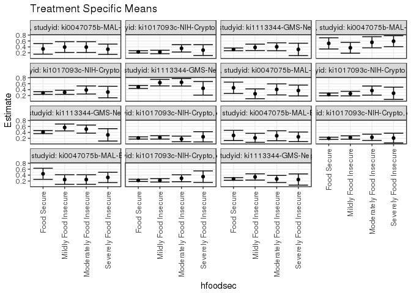

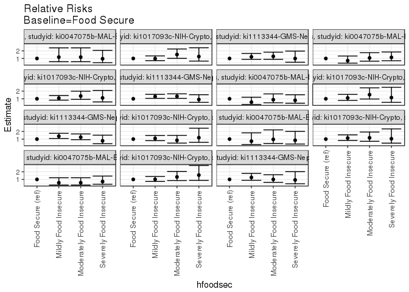

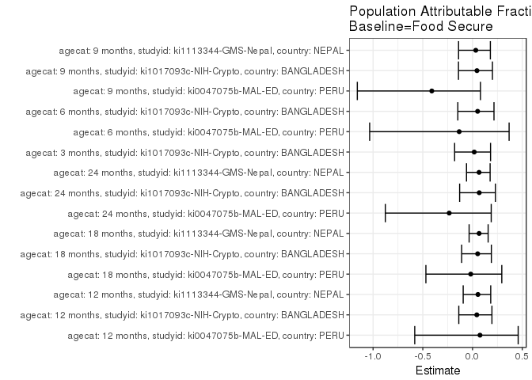

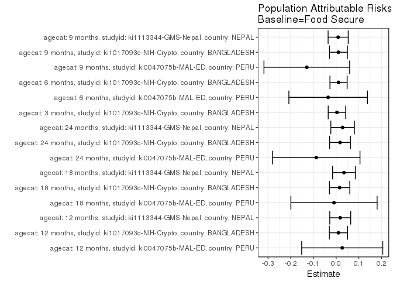

## Results Table

### Parameter: TSM

| agecat | studyid | country | intervention_level | baseline_level | estimate | ci_lower | ci_upper |
| --- | --- | --- | --- | --- | --- | --- | --- |
| 3 months | ki1017093c-NIH-Crypto | BANGLADESH | Food Secure | NA | 0.2106481 | 0.1721696 | 0.2491267 |
| 3 months | ki1017093c-NIH-Crypto | BANGLADESH | Mildly Food Insecure | NA | 0.2285714 | 0.1717391 | 0.2854038 |
| 3 months | ki1017093c-NIH-Crypto | BANGLADESH | Moderately Food Insecure | NA | 0.1774194 | 0.0822624 | 0.2725763 |
| 3 months | ki1017093c-NIH-Crypto | BANGLADESH | Severely Food Insecure | NA | 0.2500000 | 0.0766429 | 0.4233571 |
| 6 months | ki0047075b-MAL-ED | PERU | Food Secure | NA | 0.2962963 | 0.1232791 | 0.4693135 |
| 6 months | ki0047075b-MAL-ED | PERU | Mildly Food Insecure | NA | 0.2142857 | 0.0616124 | 0.3669590 |
| 6 months | ki0047075b-MAL-ED | PERU | Moderately Food Insecure | NA | 0.2857143 | 0.1176265 | 0.4538021 |
| 6 months | ki0047075b-MAL-ED | PERU | Severely Food Insecure | NA | 0.2500000 | 0.0888854 | 0.4111146 |
| 6 months | ki1017093c-NIH-Crypto | BANGLADESH | Food Secure | NA | 0.1990632 | 0.1611638 | 0.2369627 |
| 6 months | ki1017093c-NIH-Crypto | BANGLADESH | Mildly Food Insecure | NA | 0.2254902 | 0.1681031 | 0.2828773 |
| 6 months | ki1017093c-NIH-Crypto | BANGLADESH | Moderately Food Insecure | NA | 0.2333333 | 0.1262386 | 0.3404281 |
| 6 months | ki1017093c-NIH-Crypto | BANGLADESH | Severely Food Insecure | NA | 0.2083333 | 0.0457422 | 0.3709245 |
| 9 months | ki0047075b-MAL-ED | PERU | Food Secure | NA | 0.4444444 | 0.2561646 | 0.6327243 |
| 9 months | ki0047075b-MAL-ED | PERU | Mildly Food Insecure | NA | 0.2500000 | 0.0888854 | 0.4111146 |
| 9 months | ki0047075b-MAL-ED | PERU | Moderately Food Insecure | NA | 0.2500000 | 0.0888854 | 0.4111146 |
| 9 months | ki0047075b-MAL-ED | PERU | Severely Food Insecure | NA | 0.3214286 | 0.1476588 | 0.4951983 |
| 9 months | ki1017093c-NIH-Crypto | BANGLADESH | Food Secure | NA | 0.2219626 | 0.1825646 | 0.2613606 |
| 9 months | ki1017093c-NIH-Crypto | BANGLADESH | Mildly Food Insecure | NA | 0.2233503 | 0.1651495 | 0.2815510 |
| 9 months | ki1017093c-NIH-Crypto | BANGLADESH | Moderately Food Insecure | NA | 0.2931034 | 0.1758757 | 0.4103312 |
| 9 months | ki1017093c-NIH-Crypto | BANGLADESH | Severely Food Insecure | NA | 0.3478261 | 0.1530414 | 0.5426107 |
| 9 months | ki1113344-GMS-Nepal | NEPAL | Food Secure | NA | 0.2694301 | 0.2251289 | 0.3137312 |
| 9 months | ki1113344-GMS-Nepal | NEPAL | Mildly Food Insecure | NA | 0.3376623 | 0.2319343 | 0.4433903 |
| 9 months | ki1113344-GMS-Nepal | NEPAL | Moderately Food Insecure | NA | 0.2692308 | 0.1485591 | 0.3899024 |
| 9 months | ki1113344-GMS-Nepal | NEPAL | Severely Food Insecure | NA | 0.2500000 | 0.0600497 | 0.4399503 |
| 12 months | ki0047075b-MAL-ED | PERU | Food Secure | NA | 0.3333333 | 0.1547154 | 0.5119513 |
| 12 months | ki0047075b-MAL-ED | PERU | Mildly Food Insecure | NA | 0.3928571 | 0.2111395 | 0.5745747 |
| 12 months | ki0047075b-MAL-ED | PERU | Moderately Food Insecure | NA | 0.3928571 | 0.2111395 | 0.5745747 |
| 12 months | ki0047075b-MAL-ED | PERU | Severely Food Insecure | NA | 0.3214286 | 0.1476588 | 0.4951983 |
| 12 months | ki1017093c-NIH-Crypto | BANGLADESH | Food Secure | NA | 0.2318501 | 0.1917940 | 0.2719062 |
| 12 months | ki1017093c-NIH-Crypto | BANGLADESH | Mildly Food Insecure | NA | 0.2272727 | 0.1688597 | 0.2856858 |
| 12 months | ki1017093c-NIH-Crypto | BANGLADESH | Moderately Food Insecure | NA | 0.3508772 | 0.2268950 | 0.4748594 |
| 12 months | ki1017093c-NIH-Crypto | BANGLADESH | Severely Food Insecure | NA | 0.2916667 | 0.1096913 | 0.4736420 |
| 12 months | ki1113344-GMS-Nepal | NEPAL | Food Secure | NA | 0.3163265 | 0.2702480 | 0.3624051 |
| 12 months | ki1113344-GMS-Nepal | NEPAL | Mildly Food Insecure | NA | 0.3846154 | 0.2765494 | 0.4926814 |
| 12 months | ki1113344-GMS-Nepal | NEPAL | Moderately Food Insecure | NA | 0.4038462 | 0.2703603 | 0.5373320 |
| 12 months | ki1113344-GMS-Nepal | NEPAL | Severely Food Insecure | NA | 0.3157895 | 0.1065870 | 0.5249919 |
| 18 months | ki0047075b-MAL-ED | PERU | Food Secure | NA | 0.5185185 | 0.3291716 | 0.7078654 |
| 18 months | ki0047075b-MAL-ED | PERU | Mildly Food Insecure | NA | 0.3703704 | 0.1873721 | 0.5533686 |
| 18 months | ki0047075b-MAL-ED | PERU | Moderately Food Insecure | NA | 0.5555556 | 0.3672519 | 0.7438592 |
| 18 months | ki0047075b-MAL-ED | PERU | Severely Food Insecure | NA | 0.5925926 | 0.4063930 | 0.7787922 |
| 18 months | ki1017093c-NIH-Crypto | BANGLADESH | Food Secure | NA | 0.2857143 | 0.2409584 | 0.3304701 |
| 18 months | ki1017093c-NIH-Crypto | BANGLADESH | Mildly Food Insecure | NA | 0.3099415 | 0.2405709 | 0.3793122 |
| 18 months | ki1017093c-NIH-Crypto | BANGLADESH | Moderately Food Insecure | NA | 0.3877551 | 0.2512232 | 0.5242870 |
| 18 months | ki1017093c-NIH-Crypto | BANGLADESH | Severely Food Insecure | NA | 0.3181818 | 0.1233986 | 0.5129650 |
| 18 months | ki1113344-GMS-Nepal | NEPAL | Food Secure | NA | 0.4896907 | 0.4399036 | 0.5394778 |
| 18 months | ki1113344-GMS-Nepal | NEPAL | Mildly Food Insecure | NA | 0.6351351 | 0.5253513 | 0.7449190 |
| 18 months | ki1113344-GMS-Nepal | NEPAL | Moderately Food Insecure | NA | 0.6481481 | 0.5206584 | 0.7756379 |
| 18 months | ki1113344-GMS-Nepal | NEPAL | Severely Food Insecure | NA | 0.4444444 | 0.2146755 | 0.6742134 |
| 24 months | ki0047075b-MAL-ED | PERU | Food Secure | NA | 0.4615385 | 0.2690159 | 0.6540610 |
| 24 months | ki0047075b-MAL-ED | PERU | Mildly Food Insecure | NA | 0.2592593 | 0.0931838 | 0.4253347 |
| 24 months | ki0047075b-MAL-ED | PERU | Moderately Food Insecure | NA | 0.4074074 | 0.2211997 | 0.5936151 |
| 24 months | ki0047075b-MAL-ED | PERU | Severely Food Insecure | NA | 0.3703704 | 0.1873641 | 0.5533766 |
| 24 months | ki1017093c-NIH-Crypto | BANGLADESH | Food Secure | NA | 0.2395210 | 0.1937054 | 0.2853365 |
| 24 months | ki1017093c-NIH-Crypto | BANGLADESH | Mildly Food Insecure | NA | 0.2661290 | 0.1882687 | 0.3439893 |
| 24 months | ki1017093c-NIH-Crypto | BANGLADESH | Moderately Food Insecure | NA | 0.3684211 | 0.2149010 | 0.5219411 |
| 24 months | ki1017093c-NIH-Crypto | BANGLADESH | Severely Food Insecure | NA | 0.2777778 | 0.0706593 | 0.4848963 |
| 24 months | ki1113344-GMS-Nepal | NEPAL | Food Secure | NA | 0.4097421 | 0.3580937 | 0.4613905 |
| 24 months | ki1113344-GMS-Nepal | NEPAL | Mildly Food Insecure | NA | 0.5652174 | 0.4481293 | 0.6823055 |
| 24 months | ki1113344-GMS-Nepal | NEPAL | Moderately Food Insecure | NA | 0.5098039 | 0.3724646 | 0.6471433 |
| 24 months | ki1113344-GMS-Nepal | NEPAL | Severely Food Insecure | NA | 0.3157895 | 0.1065660 | 0.5250130 |

### Parameter: E(Y)

| agecat | studyid | country | intervention_level | baseline_level | estimate | ci_lower | ci_upper |
| --- | --- | --- | --- | --- | --- | --- | --- |
| 3 months | ki1017093c-NIH-Crypto | BANGLADESH | NA | NA | 0.2142857 | 0.2131965 | 0.2153749 |
| 6 months | ki0047075b-MAL-ED | PERU | NA | NA | 0.2612613 | 0.2552404 | 0.2672821 |
| 6 months | ki1017093c-NIH-Crypto | BANGLADESH | NA | NA | 0.2097902 | 0.2087908 | 0.2107896 |
| 9 months | ki0047075b-MAL-ED | PERU | NA | NA | 0.3153153 | 0.3005799 | 0.3300508 |
| 9 months | ki1017093c-NIH-Crypto | BANGLADESH | NA | NA | 0.2322946 | 0.2301736 | 0.2344157 |
| 9 months | ki1113344-GMS-Nepal | NEPAL | NA | NA | 0.2785047 | 0.2764239 | 0.2805854 |
| 12 months | ki0047075b-MAL-ED | PERU | NA | NA | 0.3603604 | 0.3541828 | 0.3665380 |
| 12 months | ki1017093c-NIH-Crypto | BANGLADESH | NA | NA | 0.2422096 | 0.2396912 | 0.2447281 |
| 12 months | ki1113344-GMS-Nepal | NEPAL | NA | NA | 0.3345656 | 0.3317990 | 0.3373322 |
| 18 months | ki0047075b-MAL-ED | PERU | NA | NA | 0.5092593 | 0.4932758 | 0.5252427 |
| 18 months | ki1017093c-NIH-Crypto | BANGLADESH | NA | NA | 0.3012618 | 0.2991172 | 0.3034065 |
| 18 months | ki1113344-GMS-Nepal | NEPAL | NA | NA | 0.5243446 | 0.5187526 | 0.5299365 |
| 24 months | ki0047075b-MAL-ED | PERU | NA | NA | 0.3738318 | 0.3597534 | 0.3879101 |
| 24 months | ki1017093c-NIH-Crypto | BANGLADESH | NA | NA | 0.2568093 | 0.2538729 | 0.2597458 |
| 24 months | ki1113344-GMS-Nepal | NEPAL | NA | NA | 0.4385246 | 0.4329219 | 0.4441273 |

### Parameter: RR

| agecat | studyid | country | intervention_level | baseline_level | estimate | ci_lower | ci_upper |
| --- | --- | --- | --- | --- | --- | --- | --- |
| 3 months | ki1017093c-NIH-Crypto | BANGLADESH | Food Secure | Food Secure | 1.0000000 | 1.0000000 | 1.000000 |
| 3 months | ki1017093c-NIH-Crypto | BANGLADESH | Mildly Food Insecure | Food Secure | 1.0850863 | 0.7970250 | 1.477259 |
| 3 months | ki1017093c-NIH-Crypto | BANGLADESH | Moderately Food Insecure | Food Secure | 0.8422545 | 0.4779422 | 1.484265 |
| 3 months | ki1017093c-NIH-Crypto | BANGLADESH | Severely Food Insecure | Food Secure | 1.1868132 | 0.5793707 | 2.431130 |
| 6 months | ki0047075b-MAL-ED | PERU | Food Secure | Food Secure | 1.0000000 | 1.0000000 | 1.000000 |
| 6 months | ki0047075b-MAL-ED | PERU | Mildly Food Insecure | Food Secure | 0.7232143 | 0.2878706 | 1.816924 |
| 6 months | ki0047075b-MAL-ED | PERU | Moderately Food Insecure | Food Secure | 0.9642857 | 0.4209368 | 2.208994 |
| 6 months | ki0047075b-MAL-ED | PERU | Severely Food Insecure | Food Secure | 0.8437500 | 0.3536114 | 2.013267 |
| 6 months | ki1017093c-NIH-Crypto | BANGLADESH | Food Secure | Food Secure | 1.0000000 | 1.0000000 | 1.000000 |
| 6 months | ki1017093c-NIH-Crypto | BANGLADESH | Mildly Food Insecure | Food Secure | 1.1327566 | 0.8243345 | 1.556574 |
| 6 months | ki1017093c-NIH-Crypto | BANGLADESH | Moderately Food Insecure | Food Secure | 1.1721569 | 0.7131575 | 1.926575 |
| 6 months | ki1017093c-NIH-Crypto | BANGLADESH | Severely Food Insecure | Food Secure | 1.0465686 | 0.4686927 | 2.336938 |
| 9 months | ki0047075b-MAL-ED | PERU | Food Secure | Food Secure | 1.0000000 | 1.0000000 | 1.000000 |
| 9 months | ki0047075b-MAL-ED | PERU | Mildly Food Insecure | Food Secure | 0.5625000 | 0.2601259 | 1.216358 |
| 9 months | ki0047075b-MAL-ED | PERU | Moderately Food Insecure | Food Secure | 0.5625000 | 0.2601259 | 1.216358 |
| 9 months | ki0047075b-MAL-ED | PERU | Severely Food Insecure | Food Secure | 0.7232143 | 0.3639004 | 1.437313 |
| 9 months | ki1017093c-NIH-Crypto | BANGLADESH | Food Secure | Food Secure | 1.0000000 | 1.0000000 | 1.000000 |
| 9 months | ki1017093c-NIH-Crypto | BANGLADESH | Mildly Food Insecure | Food Secure | 1.0062517 | 0.7341382 | 1.379226 |
| 9 months | ki1017093c-NIH-Crypto | BANGLADESH | Moderately Food Insecure | Food Secure | 1.3205082 | 0.8525236 | 2.045388 |
| 9 months | ki1017093c-NIH-Crypto | BANGLADESH | Severely Food Insecure | Food Secure | 1.5670481 | 0.8708645 | 2.819773 |
| 9 months | ki1113344-GMS-Nepal | NEPAL | Food Secure | Food Secure | 1.0000000 | 1.0000000 | 1.000000 |
| 9 months | ki1113344-GMS-Nepal | NEPAL | Mildly Food Insecure | Food Secure | 1.2532468 | 0.8799181 | 1.784970 |
| 9 months | ki1113344-GMS-Nepal | NEPAL | Moderately Food Insecure | Food Secure | 0.9992604 | 0.6199250 | 1.610713 |
| 9 months | ki1113344-GMS-Nepal | NEPAL | Severely Food Insecure | Food Secure | 0.9278846 | 0.4264599 | 2.018876 |
| 12 months | ki0047075b-MAL-ED | PERU | Food Secure | Food Secure | 1.0000000 | 1.0000000 | 1.000000 |
| 12 months | ki0047075b-MAL-ED | PERU | Mildly Food Insecure | Food Secure | 1.1785714 | 0.5806670 | 2.392130 |
| 12 months | ki0047075b-MAL-ED | PERU | Moderately Food Insecure | Food Secure | 1.1785714 | 0.5806670 | 2.392130 |
| 12 months | ki0047075b-MAL-ED | PERU | Severely Food Insecure | Food Secure | 0.9642857 | 0.4504289 | 2.064359 |
| 12 months | ki1017093c-NIH-Crypto | BANGLADESH | Food Secure | Food Secure | 1.0000000 | 1.0000000 | 1.000000 |
| 12 months | ki1017093c-NIH-Crypto | BANGLADESH | Mildly Food Insecure | Food Secure | 0.9802571 | 0.7191911 | 1.336090 |
| 12 months | ki1017093c-NIH-Crypto | BANGLADESH | Moderately Food Insecure | Food Secure | 1.5133794 | 1.0212430 | 2.242676 |
| 12 months | ki1017093c-NIH-Crypto | BANGLADESH | Severely Food Insecure | Food Secure | 1.2579966 | 0.6584455 | 2.403472 |
| 12 months | ki1113344-GMS-Nepal | NEPAL | Food Secure | Food Secure | 1.0000000 | 1.0000000 | 1.000000 |
| 12 months | ki1113344-GMS-Nepal | NEPAL | Mildly Food Insecure | Food Secure | 1.2158809 | 0.8860177 | 1.668552 |
| 12 months | ki1113344-GMS-Nepal | NEPAL | Moderately Food Insecure | Food Secure | 1.2766749 | 0.8896278 | 1.832113 |
| 12 months | ki1113344-GMS-Nepal | NEPAL | Severely Food Insecure | Food Secure | 0.9983022 | 0.5066172 | 1.967180 |
| 18 months | ki0047075b-MAL-ED | PERU | Food Secure | Food Secure | 1.0000000 | 1.0000000 | 1.000000 |
| 18 months | ki0047075b-MAL-ED | PERU | Mildly Food Insecure | Food Secure | 0.7142857 | 0.3864066 | 1.320381 |
| 18 months | ki0047075b-MAL-ED | PERU | Moderately Food Insecure | Food Secure | 1.0714286 | 0.6510055 | 1.763363 |
| 18 months | ki0047075b-MAL-ED | PERU | Severely Food Insecure | Food Secure | 1.1428571 | 0.7059486 | 1.850166 |
| 18 months | ki1017093c-NIH-Crypto | BANGLADESH | Food Secure | Food Secure | 1.0000000 | 1.0000000 | 1.000000 |
| 18 months | ki1017093c-NIH-Crypto | BANGLADESH | Mildly Food Insecure | Food Secure | 1.0847953 | 0.8254735 | 1.425583 |
| 18 months | ki1017093c-NIH-Crypto | BANGLADESH | Moderately Food Insecure | Food Secure | 1.3571429 | 0.9231172 | 1.995236 |
| 18 months | ki1017093c-NIH-Crypto | BANGLADESH | Severely Food Insecure | Food Secure | 1.1136364 | 0.5919880 | 2.094951 |
| 18 months | ki1113344-GMS-Nepal | NEPAL | Food Secure | Food Secure | 1.0000000 | 1.0000000 | 1.000000 |
| 18 months | ki1113344-GMS-Nepal | NEPAL | Mildly Food Insecure | Food Secure | 1.2970128 | 1.0613360 | 1.585023 |
| 18 months | ki1113344-GMS-Nepal | NEPAL | Moderately Food Insecure | Food Secure | 1.3235867 | 1.0606951 | 1.651636 |
| 18 months | ki1113344-GMS-Nepal | NEPAL | Severely Food Insecure | Food Secure | 0.9076023 | 0.5358872 | 1.537156 |
| 24 months | ki0047075b-MAL-ED | PERU | Food Secure | Food Secure | 1.0000000 | 1.0000000 | 1.000000 |
| 24 months | ki0047075b-MAL-ED | PERU | Mildly Food Insecure | Food Secure | 0.5617284 | 0.2615430 | 1.206451 |
| 24 months | ki0047075b-MAL-ED | PERU | Moderately Food Insecure | Food Secure | 0.8827160 | 0.4754279 | 1.638918 |
| 24 months | ki0047075b-MAL-ED | PERU | Severely Food Insecure | Food Secure | 0.8024691 | 0.4203332 | 1.532015 |
| 24 months | ki1017093c-NIH-Crypto | BANGLADESH | Food Secure | Food Secure | 1.0000000 | 1.0000000 | 1.000000 |
| 24 months | ki1017093c-NIH-Crypto | BANGLADESH | Mildly Food Insecure | Food Secure | 1.1110887 | 0.7833260 | 1.575995 |
| 24 months | ki1017093c-NIH-Crypto | BANGLADESH | Moderately Food Insecure | Food Secure | 1.5381579 | 0.9724689 | 2.432911 |
| 24 months | ki1017093c-NIH-Crypto | BANGLADESH | Severely Food Insecure | Food Secure | 1.1597222 | 0.5370896 | 2.504155 |
| 24 months | ki1113344-GMS-Nepal | NEPAL | Food Secure | Food Secure | 1.0000000 | 1.0000000 | 1.000000 |
| 24 months | ki1113344-GMS-Nepal | NEPAL | Mildly Food Insecure | Food Secure | 1.3794466 | 1.0824103 | 1.757996 |
| 24 months | ki1113344-GMS-Nepal | NEPAL | Moderately Food Insecure | Food Secure | 1.2442068 | 0.9241050 | 1.675189 |
| 24 months | ki1113344-GMS-Nepal | NEPAL | Severely Food Insecure | Food Secure | 0.7707030 | 0.3926340 | 1.512816 |

### Parameter: PAR

| agecat | studyid | country | intervention_level | baseline_level | estimate | ci_lower | ci_upper |
| --- | --- | --- | --- | --- | --- | --- | --- |
| 3 months | ki1017093c-NIH-Crypto | BANGLADESH | Food Secure | NA | 0.0036376 | -0.0348564 | 0.0421315 |
| 6 months | ki0047075b-MAL-ED | PERU | Food Secure | NA | -0.0350350 | -0.2081570 | 0.1380869 |
| 6 months | ki1017093c-NIH-Crypto | BANGLADESH | Food Secure | NA | 0.0107270 | -0.0271856 | 0.0486396 |
| 9 months | ki0047075b-MAL-ED | PERU | Food Secure | NA | -0.1291291 | -0.3179847 | 0.0597265 |
| 9 months | ki1017093c-NIH-Crypto | BANGLADESH | Food Secure | NA | 0.0103320 | -0.0291231 | 0.0497871 |
| 9 months | ki1113344-GMS-Nepal | NEPAL | Food Secure | NA | 0.0090746 | -0.0352753 | 0.0534246 |
| 12 months | ki0047075b-MAL-ED | PERU | Food Secure | NA | 0.0270270 | -0.1516977 | 0.2057518 |
| 12 months | ki1017093c-NIH-Crypto | BANGLADESH | Food Secure | NA | 0.0103595 | -0.0297757 | 0.0504947 |
| 12 months | ki1113344-GMS-Nepal | NEPAL | Food Secure | NA | 0.0182391 | -0.0279225 | 0.0644006 |
| 18 months | ki0047075b-MAL-ED | PERU | Food Secure | NA | -0.0092593 | -0.1992795 | 0.1807610 |
| 18 months | ki1017093c-NIH-Crypto | BANGLADESH | Food Secure | NA | 0.0155475 | -0.0292597 | 0.0603547 |
| 18 months | ki1113344-GMS-Nepal | NEPAL | Food Secure | NA | 0.0346538 | -0.0154463 | 0.0847540 |
| 24 months | ki0047075b-MAL-ED | PERU | Food Secure | NA | -0.0877067 | -0.2807433 | 0.1053299 |
| 24 months | ki1017093c-NIH-Crypto | BANGLADESH | Food Secure | NA | 0.0172884 | -0.0286212 | 0.0631980 |
| 24 months | ki1113344-GMS-Nepal | NEPAL | Food Secure | NA | 0.0287825 | -0.0231689 | 0.0807339 |

### Parameter: PAF

| agecat | studyid | country | intervention_level | baseline_level | estimate | ci_lower | ci_upper |
| --- | --- | --- | --- | --- | --- | --- | --- |
| 3 months | ki1017093c-NIH-Crypto | BANGLADESH | Food Secure | NA | 0.0169753 | -0.1801212 | 0.1811540 |
| 6 months | ki0047075b-MAL-ED | PERU | Food Secure | NA | -0.1340996 | -1.0344526 | 0.3677995 |
| 6 months | ki1017093c-NIH-Crypto | BANGLADESH | Food Secure | NA | 0.0511319 | -0.1479331 | 0.2156767 |
| 9 months | ki0047075b-MAL-ED | PERU | Food Secure | NA | -0.4095238 | -1.1585818 | 0.0796006 |
| 9 months | ki1017093c-NIH-Crypto | BANGLADESH | Food Secure | NA | 0.0444780 | -0.1413771 | 0.2000696 |
| 9 months | ki1113344-GMS-Nepal | NEPAL | Food Secure | NA | 0.0325834 | -0.1405024 | 0.1794012 |
| 12 months | ki0047075b-MAL-ED | PERU | Food Secure | NA | 0.0750000 | -0.5811722 | 0.4588666 |
| 12 months | ki1017093c-NIH-Crypto | BANGLADESH | Food Secure | NA | 0.0427709 | -0.1381081 | 0.1949028 |
| 12 months | ki1113344-GMS-Nepal | NEPAL | Food Secure | NA | 0.0545157 | -0.0940039 | 0.1828726 |
| 18 months | ki0047075b-MAL-ED | PERU | Food Secure | NA | -0.0181818 | -0.4689293 | 0.2942518 |
| 18 months | ki1017093c-NIH-Crypto | BANGLADESH | Food Secure | NA | 0.0516081 | -0.1094004 | 0.1892492 |
| 18 months | ki1113344-GMS-Nepal | NEPAL | Food Secure | NA | 0.0660898 | -0.0344328 | 0.1568441 |
| 24 months | ki0047075b-MAL-ED | PERU | Food Secure | NA | -0.2346154 | -0.8768377 | 0.1878492 |
| 24 months | ki1017093c-NIH-Crypto | BANGLADESH | Food Secure | NA | 0.0673199 | -0.1296733 | 0.2299613 |
| 24 months | ki1113344-GMS-Nepal | NEPAL | Food Secure | NA | 0.0656348 | -0.0605726 | 0.1768236 |